# Risk Factor Analysis

## Outcome Variable

**Outcome Variable:** stunted

## Predictor Variables

**Intervention Variable:** tr

**Adjustment Set:**

unadjusted

## Stratifying Variables

The analysis was stratified on these variable(s):

- vagbrth
- agecat
- studyid
- country

## Data Summary

| vagbrth | agecat | studyid | country | tr | stunted | n_cell | n |
| --- | --- | --- | --- | --- | --- | --- | --- |
| 0 | 6 months | ki1017093b-PROVIDE | BANGLADESH | Control | 0 | 0 | 13 |
| 0 | 6 months | ki1017093b-PROVIDE | BANGLADESH | Control | 1 | 2 | 13 |
| 0 | 6 months | ki1017093b-PROVIDE | BANGLADESH | Other | 0 | 9 | 13 |
| 0 | 6 months | ki1017093b-PROVIDE | BANGLADESH | Other | 1 | 2 | 13 |
| 1 | 6 months | ki1017093b-PROVIDE | BANGLADESH | Control | 0 | 8 | 33 |
| 1 | 6 months | ki1017093b-PROVIDE | BANGLADESH | Control | 1 | 0 | 33 |
| 1 | 6 months | ki1017093b-PROVIDE | BANGLADESH | Other | 0 | 19 | 33 |
| 1 | 6 months | ki1017093b-PROVIDE | BANGLADESH | Other | 1 | 6 | 33 |
| 0 | 24 months | ki1017093b-PROVIDE | BANGLADESH | Other | 0 | 2 | 2 |
| 1 | 6 months | ki1066203-TanzaniaChild2 | TANZANIA, UNITED REPUBLIC OF | Control | 0 | 344 | 1528 |
| 1 | 6 months | ki1066203-TanzaniaChild2 | TANZANIA, UNITED REPUBLIC OF | Control | 1 | 43 | 1528 |
| 1 | 6 months | ki1066203-TanzaniaChild2 | TANZANIA, UNITED REPUBLIC OF | Other | 0 | 333 | 1528 |
| 1 | 6 months | ki1066203-TanzaniaChild2 | TANZANIA, UNITED REPUBLIC OF | Other | 1 | 42 | 1528 |
| 1 | 6 months | ki1066203-TanzaniaChild2 | TANZANIA, UNITED REPUBLIC OF | Zinc | 0 | 677 | 1528 |
| 1 | 6 months | ki1066203-TanzaniaChild2 | TANZANIA, UNITED REPUBLIC OF | Zinc | 1 | 89 | 1528 |
| 0 | 6 months | ki1066203-TanzaniaChild2 | TANZANIA, UNITED REPUBLIC OF | Control | 0 | 32 | 160 |
| 0 | 6 months | ki1066203-TanzaniaChild2 | TANZANIA, UNITED REPUBLIC OF | Control | 1 | 4 | 160 |
| 0 | 6 months | ki1066203-TanzaniaChild2 | TANZANIA, UNITED REPUBLIC OF | Other | 0 | 42 | 160 |
| 0 | 6 months | ki1066203-TanzaniaChild2 | TANZANIA, UNITED REPUBLIC OF | Other | 1 | 3 | 160 |
| 0 | 6 months | ki1066203-TanzaniaChild2 | TANZANIA, UNITED REPUBLIC OF | Zinc | 0 | 74 | 160 |
| 0 | 6 months | ki1066203-TanzaniaChild2 | TANZANIA, UNITED REPUBLIC OF | Zinc | 1 | 5 | 160 |
| 1 | 24 months | ki1066203-TanzaniaChild2 | TANZANIA, UNITED REPUBLIC OF | Other | 0 | 2 | 3 |
| 1 | 24 months | ki1066203-TanzaniaChild2 | TANZANIA, UNITED REPUBLIC OF | Other | 1 | 0 | 3 |
| 1 | 24 months | ki1066203-TanzaniaChild2 | TANZANIA, UNITED REPUBLIC OF | Zinc | 0 | 0 | 3 |
| 1 | 24 months | ki1066203-TanzaniaChild2 | TANZANIA, UNITED REPUBLIC OF | Zinc | 1 | 1 | 3 |
| 0 | 24 months | ki1066203-TanzaniaChild2 | TANZANIA, UNITED REPUBLIC OF | Control | 0 | 1 | 1 |
| 1 | Birth | ki1119695-PROBIT | BELARUS | Control | 0 | 6045 | 12287 |
| 1 | Birth | ki1119695-PROBIT | BELARUS | Control | 1 | 18 | 12287 |
| 1 | Birth | ki1119695-PROBIT | BELARUS | Maternal | 0 | 6212 | 12287 |
| 1 | Birth | ki1119695-PROBIT | BELARUS | Maternal | 1 | 12 | 12287 |

[output cut: 125 more lines]

The following strata were considered:

- vagbrth: 0, agecat: 24 months, studyid: iLiNS_DYADM_LNS, country: MALAWI
- vagbrth: 0, agecat: 24 months, studyid: ki1017093b-PROVIDE, country: BANGLADESH
- vagbrth: 0, agecat: 24 months, studyid: ki1066203-TanzaniaChild2, country: TANZANIA, UNITED REPUBLIC OF
- vagbrth: 0, agecat: 24 months, studyid: ki1119695-PROBIT, country: BELARUS
- vagbrth: 0, agecat: 24 months, studyid: ki1126311-ZVITAMBO, country: ZIMBABWE
- vagbrth: 0, agecat: 24 months, studyid: ki1148112-iLiNS-DYAD-M, country: MALAWI
- vagbrth: 0, agecat: 24 months, studyid: kiGH5241-JiVitA-3, country: BANGLADESH
- vagbrth: 0, agecat: 24 months, studyid: kiGH5241-JiVitA-4, country: BANGLADESH
- vagbrth: 0, agecat: 6 months, studyid: iLiNS_DYADM_LNS, country: MALAWI
- vagbrth: 0, agecat: 6 months, studyid: ki1017093b-PROVIDE, country: BANGLADESH
- vagbrth: 0, agecat: 6 months, studyid: ki1066203-TanzaniaChild2, country: TANZANIA, UNITED REPUBLIC OF
- vagbrth: 0, agecat: 6 months, studyid: ki1119695-PROBIT, country: BELARUS
- vagbrth: 0, agecat: 6 months, studyid: ki1126311-ZVITAMBO, country: ZIMBABWE
- vagbrth: 0, agecat: 6 months, studyid: ki1148112-iLiNS-DYAD-M, country: MALAWI
- vagbrth: 0, agecat: 6 months, studyid: kiGH5241-JiVitA-3, country: BANGLADESH
- vagbrth: 0, agecat: 6 months, studyid: kiGH5241-JiVitA-4, country: BANGLADESH
- vagbrth: 0, agecat: Birth, studyid: ki1119695-PROBIT, country: BELARUS
- vagbrth: 0, agecat: Birth, studyid: ki1126311-ZVITAMBO, country: ZIMBABWE
- vagbrth: 0, agecat: Birth, studyid: kiGH5241-JiVitA-3, country: BANGLADESH
- vagbrth: 0, agecat: Birth, studyid: kiGH5241-JiVitA-4, country: BANGLADESH
- vagbrth: 1, agecat: 24 months, studyid: iLiNS_DYADM_LNS, country: MALAWI
- vagbrth: 1, agecat: 24 months, studyid: ki1066203-TanzaniaChild2, country: TANZANIA, UNITED REPUBLIC OF
- vagbrth: 1, agecat: 24 months, studyid: ki1119695-PROBIT, country: BELARUS
- vagbrth: 1, agecat: 24 months, studyid: ki1126311-ZVITAMBO, country: ZIMBABWE
- vagbrth: 1, agecat: 24 months, studyid: ki1148112-iLiNS-DYAD-M, country: MALAWI
- vagbrth: 1, agecat: 24 months, studyid: kiGH5241-JiVitA-3, country: BANGLADESH
- vagbrth: 1, agecat: 24 months, studyid: kiGH5241-JiVitA-4, country: BANGLADESH
- vagbrth: 1, agecat: 6 months, studyid: iLiNS_DYADM_LNS, country: MALAWI
- vagbrth: 1, agecat: 6 months, studyid: ki1017093b-PROVIDE, country: BANGLADESH
- vagbrth: 1, agecat: 6 months, studyid: ki1066203-TanzaniaChild2, country: TANZANIA, UNITED REPUBLIC OF
- vagbrth: 1, agecat: 6 months, studyid: ki1119695-PROBIT, country: BELARUS
- vagbrth: 1, agecat: 6 months, studyid: ki1126311-ZVITAMBO, country: ZIMBABWE
- vagbrth: 1, agecat: 6 months, studyid: ki1148112-iLiNS-DYAD-M, country: MALAWI
- vagbrth: 1, agecat: 6 months, studyid: kiGH5241-JiVitA-3, country: BANGLADESH
- vagbrth: 1, agecat: 6 months, studyid: kiGH5241-JiVitA-4, country: BANGLADESH
- vagbrth: 1, agecat: Birth, studyid: iLiNS_DYADM_LNS, country: MALAWI
- vagbrth: 1, agecat: Birth, studyid: ki1119695-PROBIT, country: BELARUS
- vagbrth: 1, agecat: Birth, studyid: ki1126311-ZVITAMBO, country: ZIMBABWE
- vagbrth: 1, agecat: Birth, studyid: ki1148112-iLiNS-DYAD-M, country: MALAWI
- vagbrth: 1, agecat: Birth, studyid: kiGH5241-JiVitA-3, country: BANGLADESH
- vagbrth: 1, agecat: Birth, studyid: kiGH5241-JiVitA-4, country: BANGLADESH

### Dropped Strata

Some strata were dropped due to rare outcomes:

- vagbrth: 0, agecat: 6 months, studyid: ki1017093b-PROVIDE, country: BANGLADESH
- vagbrth: 1, agecat: 6 months, studyid: ki1017093b-PROVIDE, country: BANGLADESH
- vagbrth: 0, agecat: 24 months, studyid: ki1017093b-PROVIDE, country: BANGLADESH
- vagbrth: 0, agecat: 6 months, studyid: ki1066203-TanzaniaChild2, country: TANZANIA, UNITED REPUBLIC OF
- vagbrth: 1, agecat: 24 months, studyid: ki1066203-TanzaniaChild2, country: TANZANIA, UNITED REPUBLIC OF
- vagbrth: 0, agecat: 24 months, studyid: ki1066203-TanzaniaChild2, country: TANZANIA, UNITED REPUBLIC OF
- vagbrth: 0, agecat: Birth, studyid: ki1119695-PROBIT, country: BELARUS
- vagbrth: 0, agecat: 24 months, studyid: ki1119695-PROBIT, country: BELARUS
- vagbrth: 0, agecat: 24 months, studyid: ki1126311-ZVITAMBO, country: ZIMBABWE
- vagbrth: 1, agecat: Birth, studyid: ki1148112-iLiNS-DYAD-M, country: MALAWI
- vagbrth: 0, agecat: 24 months, studyid: ki1148112-iLiNS-DYAD-M, country: MALAWI
- vagbrth: 1, agecat: 24 months, studyid: ki1148112-iLiNS-DYAD-M, country: MALAWI
- vagbrth: 0, agecat: 24 months, studyid: kiGH5241-JiVitA-3, country: BANGLADESH
- vagbrth: 0, agecat: Birth, studyid: kiGH5241-JiVitA-3, country: BANGLADESH
- vagbrth: 0, agecat: 24 months, studyid: kiGH5241-JiVitA-4, country: BANGLADESH
- vagbrth: 0, agecat: Birth, studyid: kiGH5241-JiVitA-4, country: BANGLADESH
- vagbrth: 1, agecat: Birth, studyid: iLiNS_DYADM_LNS, country: MALAWI
- vagbrth: 0, agecat: 24 months, studyid: iLiNS_DYADM_LNS, country: MALAWI
- vagbrth: 1, agecat: 24 months, studyid: iLiNS_DYADM_LNS, country: MALAWI

## Methods Detail

We’re interested in the causal parameters $E[Y_a]$ for all values of $a \in \mathcal{A}$. These parameters represent the mean outcome if, possibly contrary to fact, we intervened to set all units to have $A=a$. Under the randomization and positivity assumptions, these are identified by the statistical parameters $\psi_a=E_W[E_{Y|A,W}(Y|A=a,W)]$. In addition, we’re interested in the mean of $Y$, $E[Y]$ under no intervention (the observed mean). We will estimate these parameters by using SuperLearner to fit the relevant likelihood factors – $E_{Y|A,W}(Y|A=a,W)$ and $p(A=a|W)$, and then updating our likelihood fit using a joint TMLE.

For unadjusted analyses ($W=\{\}$), initial likelihoods were estimated using Lrnr_glm to estimate the simple $E(Y|A)$ and Lrnr_mean to estimate $p(A)$. For adjusted analyses, a small library containing Lrnr_glmnet, Lrnr_xgboost, and Lrnr_mean was used.

Having estimated these parameters, we will then use the delta method to estimate relative risks and attributable risks relative to a prespecified baseline level of $A$.

# Results Detail

## Results Plots

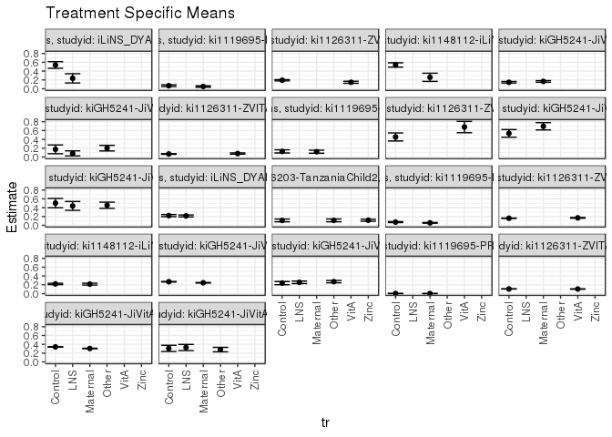

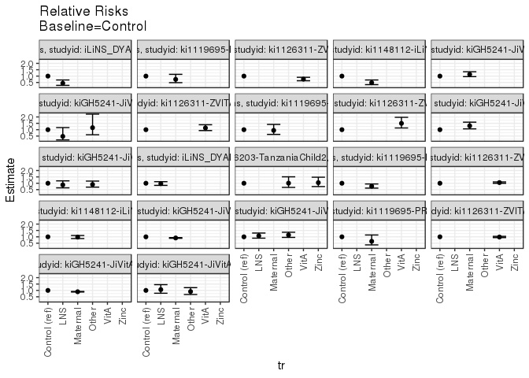

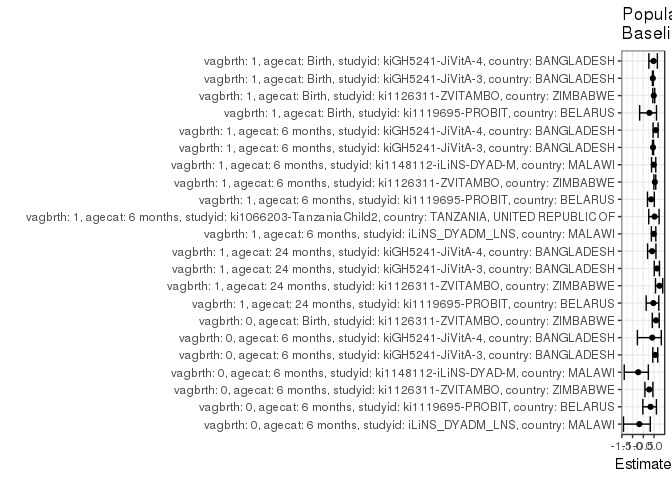

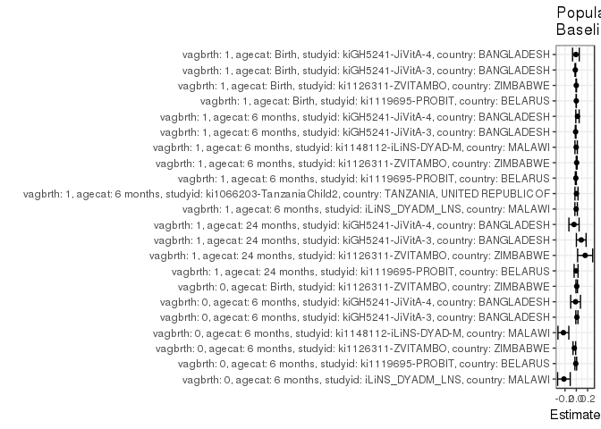

## Results Table

### Parameter: TSM

| vagbrth | agecat | studyid | country | intervention_level | baseline_level | estimate | ci_lower | ci_upper |
| --- | --- | --- | --- | --- | --- | --- | --- | --- |
| 0 | Birth | ki1126311-ZVITAMBO | ZIMBABWE | Control | NA | 0.0694444 | 0.0621647 | 0.0767242 |
| 0 | Birth | ki1126311-ZVITAMBO | ZIMBABWE | VitA | NA | 0.0789474 | 0.0654951 | 0.0923996 |
| 0 | 6 months | iLiNS_DYADM_LNS | MALAWI | Control | NA | 0.5384615 | 0.4626957 | 0.6142273 |
| 0 | 6 months | iLiNS_DYADM_LNS | MALAWI | LNS | NA | 0.2352941 | 0.1310354 | 0.3395529 |
| 0 | 6 months | ki1119695-PROBIT | BELARUS | Control | NA | 0.0680908 | 0.0481785 | 0.0880031 |
| 0 | 6 months | ki1119695-PROBIT | BELARUS | Maternal | NA | 0.0507166 | 0.0352848 | 0.0661485 |
| 0 | 6 months | ki1126311-ZVITAMBO | ZIMBABWE | Control | NA | 0.1923077 | 0.1778756 | 0.2067398 |
| 0 | 6 months | ki1126311-ZVITAMBO | ZIMBABWE | VitA | NA | 0.1461988 | 0.1227373 | 0.1696603 |
| 0 | 6 months | ki1148112-iLiNS-DYAD-M | MALAWI | Control | NA | 0.5384615 | 0.4884900 | 0.5884331 |
| 0 | 6 months | ki1148112-iLiNS-DYAD-M | MALAWI | Maternal | NA | 0.2586207 | 0.1659087 | 0.3513326 |
| 0 | 6 months | kiGH5241-JiVitA-3 | BANGLADESH | Control | NA | 0.1461101 | 0.1281476 | 0.1640725 |
| 0 | 6 months | kiGH5241-JiVitA-3 | BANGLADESH | Maternal | NA | 0.1657559 | 0.1466793 | 0.1848325 |
| 0 | 6 months | kiGH5241-JiVitA-4 | BANGLADESH | Control | NA | 0.1739130 | 0.0748919 | 0.2729342 |
| 0 | 6 months | kiGH5241-JiVitA-4 | BANGLADESH | LNS | NA | 0.0824742 | 0.0252494 | 0.1396990 |
| 0 | 6 months | kiGH5241-JiVitA-4 | BANGLADESH | Other | NA | 0.2012195 | 0.1379245 | 0.2645145 |
| 1 | Birth | ki1119695-PROBIT | BELARUS | Control | NA | 0.0029688 | 0.0017151 | 0.0042225 |
| 1 | Birth | ki1119695-PROBIT | BELARUS | Maternal | NA | 0.0019280 | 0.0012029 | 0.0026532 |
| 1 | Birth | ki1126311-ZVITAMBO | ZIMBABWE | Control | NA | 0.1063898 | 0.1036965 | 0.1090830 |
| 1 | Birth | ki1126311-ZVITAMBO | ZIMBABWE | VitA | NA | 0.1048387 | 0.1001956 | 0.1094819 |
| 1 | Birth | kiGH5241-JiVitA-3 | BANGLADESH | Control | NA | 0.3411100 | 0.3358456 | 0.3463743 |
| 1 | Birth | kiGH5241-JiVitA-3 | BANGLADESH | Maternal | NA | 0.3052877 | 0.2999387 | 0.3106367 |
| 1 | Birth | kiGH5241-JiVitA-4 | BANGLADESH | Control | NA | 0.3080357 | 0.2379793 | 0.3780922 |
| 1 | Birth | kiGH5241-JiVitA-4 | BANGLADESH | LNS | NA | 0.3274336 | 0.2576156 | 0.3972517 |
| 1 | Birth | kiGH5241-JiVitA-4 | BANGLADESH | Other | NA | 0.2803235 | 0.2295359 | 0.3311110 |
| 1 | 6 months | iLiNS_DYADM_LNS | MALAWI | Control | NA | 0.2205438 | 0.1969076 | 0.2441800 |
| 1 | 6 months | iLiNS_DYADM_LNS | MALAWI | LNS | NA | 0.2135593 | 0.1915035 | 0.2356152 |
| 1 | 6 months | ki1066203-TanzaniaChild2 | TANZANIA, UNITED REPUBLIC OF | Control | NA | 0.1111111 | 0.0797900 | 0.1424322 |
| 1 | 6 months | ki1066203-TanzaniaChild2 | TANZANIA, UNITED REPUBLIC OF | Other | NA | 0.1120000 | 0.0800706 | 0.1439294 |
| 1 | 6 months | ki1066203-TanzaniaChild2 | TANZANIA, UNITED REPUBLIC OF | Zinc | NA | 0.1161880 | 0.0934874 | 0.1388885 |
| 1 | 6 months | ki1119695-PROBIT | BELARUS | Control | NA | 0.0730787 | 0.0617952 | 0.0843623 |
| 1 | 6 months | ki1119695-PROBIT | BELARUS | Maternal | NA | 0.0558556 | 0.0478029 | 0.0639083 |
| 1 | 6 months | ki1126311-ZVITAMBO | ZIMBABWE | Control | NA | 0.1610315 | 0.1567584 | 0.1653047 |
| 1 | 6 months | ki1126311-ZVITAMBO | ZIMBABWE | VitA | NA | 0.1694979 | 0.1618976 | 0.1770982 |
| 1 | 6 months | ki1148112-iLiNS-DYAD-M | MALAWI | Control | NA | 0.2205438 | 0.2048407 | 0.2362469 |
| 1 | 6 months | ki1148112-iLiNS-DYAD-M | MALAWI | Maternal | NA | 0.2160393 | 0.1948624 | 0.2372162 |
| 1 | 6 months | kiGH5241-JiVitA-3 | BANGLADESH | Control | NA | 0.2701655 | 0.2641092 | 0.2762218 |
| 1 | 6 months | kiGH5241-JiVitA-3 | BANGLADESH | Maternal | NA | 0.2462848 | 0.2404972 | 0.2520723 |
| 1 | 6 months | kiGH5241-JiVitA-4 | BANGLADESH | Control | NA | 0.2382413 | 0.2026215 | 0.2738611 |
| 1 | 6 months | kiGH5241-JiVitA-4 | BANGLADESH | LNS | NA | 0.2567164 | 0.2284344 | 0.2849984 |
| 1 | 6 months | kiGH5241-JiVitA-4 | BANGLADESH | Other | NA | 0.2718219 | 0.2460402 | 0.2976036 |
| 1 | 24 months | ki1119695-PROBIT | BELARUS | Control | NA | 0.1275964 | 0.0922272 | 0.1629656 |
| 1 | 24 months | ki1119695-PROBIT | BELARUS | Maternal | NA | 0.1203931 | 0.0854257 | 0.1553606 |
| 1 | 24 months | ki1126311-ZVITAMBO | ZIMBABWE | Control | NA | 0.4545455 | 0.3633597 | 0.5457312 |
| 1 | 24 months | ki1126311-ZVITAMBO | ZIMBABWE | VitA | NA | 0.6800000 | 0.5512159 | 0.8087841 |
| 1 | 24 months | kiGH5241-JiVitA-3 | BANGLADESH | Control | NA | 0.5357143 | 0.4490554 | 0.6223732 |
| 1 | 24 months | kiGH5241-JiVitA-3 | BANGLADESH | Maternal | NA | 0.6969697 | 0.6142454 | 0.7796940 |
| 1 | 24 months | kiGH5241-JiVitA-4 | BANGLADESH | Control | NA | 0.5044248 | 0.3991705 | 0.6096790 |
| 1 | 24 months | kiGH5241-JiVitA-4 | BANGLADESH | LNS | NA | 0.4400000 | 0.3398171 | 0.5401829 |
| 1 | 24 months | kiGH5241-JiVitA-4 | BANGLADESH | Other | NA | 0.4553991 | 0.3851761 | 0.5256220 |

### Parameter: E(Y)

| vagbrth | agecat | studyid | country | intervention_level | baseline_level | estimate | ci_lower | ci_upper |
| --- | --- | --- | --- | --- | --- | --- | --- | --- |
| 0 | Birth | ki1126311-ZVITAMBO | ZIMBABWE | NA | NA | 0.0765921 | 0.0612946 | 0.0918896 |
| 0 | 6 months | iLiNS_DYADM_LNS | MALAWI | NA | NA | 0.3191489 | 0.1844414 | 0.4538565 |
| 0 | 6 months | ki1119695-PROBIT | BELARUS | NA | NA | 0.0585749 | 0.0331645 | 0.0839852 |
| 0 | 6 months | ki1126311-ZVITAMBO | ZIMBABWE | NA | NA | 0.1569507 | 0.1293660 | 0.1845354 |
| 0 | 6 months | ki1148112-iLiNS-DYAD-M | MALAWI | NA | NA | 0.3098592 | 0.2015288 | 0.4181895 |
| 0 | 6 months | kiGH5241-JiVitA-3 | BANGLADESH | NA | NA | 0.1561338 | 0.1299192 | 0.1823485 |
| 0 | 6 months | kiGH5241-JiVitA-4 | BANGLADESH | NA | NA | 0.1606061 | 0.1189146 | 0.2022975 |
| 1 | Birth | ki1119695-PROBIT | BELARUS | NA | NA | 0.0024416 | 0.0009778 | 0.0039054 |
| 1 | Birth | ki1126311-ZVITAMBO | ZIMBABWE | NA | NA | 0.1052254 | 0.0998577 | 0.1105932 |
| 1 | Birth | kiGH5241-JiVitA-3 | BANGLADESH | NA | NA | 0.3230864 | 0.3154240 | 0.3307487 |
| 1 | Birth | kiGH5241-JiVitA-4 | BANGLADESH | NA | NA | 0.3008526 | 0.2652718 | 0.3364334 |
| 1 | 6 months | iLiNS_DYADM_LNS | MALAWI | NA | NA | 0.2172524 | 0.1849227 | 0.2495821 |
| 1 | 6 months | ki1066203-TanzaniaChild2 | TANZANIA, UNITED REPUBLIC OF | NA | NA | 0.1138743 | 0.0979417 | 0.1298070 |
| 1 | 6 months | ki1119695-PROBIT | BELARUS | NA | NA | 0.0643880 | 0.0497016 | 0.0790745 |
| 1 | 6 months | ki1126311-ZVITAMBO | ZIMBABWE | NA | NA | 0.1674003 | 0.1586807 | 0.1761199 |
| 1 | 6 months | ki1148112-iLiNS-DYAD-M | MALAWI | NA | NA | 0.2176221 | 0.1912580 | 0.2439862 |
| 1 | 6 months | kiGH5241-JiVitA-3 | BANGLADESH | NA | NA | 0.2581203 | 0.2496870 | 0.2665536 |
| 1 | 6 months | kiGH5241-JiVitA-4 | BANGLADESH | NA | NA | 0.2588076 | 0.2417405 | 0.2758746 |
| 1 | 24 months | ki1119695-PROBIT | BELARUS | NA | NA | 0.1236559 | 0.0742959 | 0.1730159 |
| 1 | 24 months | ki1126311-ZVITAMBO | ZIMBABWE | NA | NA | 0.6111111 | 0.4496058 | 0.7726165 |
| 1 | 24 months | kiGH5241-JiVitA-3 | BANGLADESH | NA | NA | 0.6229508 | 0.5010897 | 0.7448119 |
| 1 | 24 months | kiGH5241-JiVitA-4 | BANGLADESH | NA | NA | 0.4634146 | 0.4127492 | 0.5140801 |

### Parameter: RR

| vagbrth | agecat | studyid | country | intervention_level | baseline_level | estimate | ci_lower | ci_upper |
| --- | --- | --- | --- | --- | --- | --- | --- | --- |
| 0 | Birth | ki1126311-ZVITAMBO | ZIMBABWE | Control | Control | 1.0000000 | 1.0000000 | 1.0000000 |
| 0 | Birth | ki1126311-ZVITAMBO | ZIMBABWE | VitA | Control | 1.1368421 | 0.9307128 | 1.3886238 |
| 0 | 6 months | iLiNS_DYADM_LNS | MALAWI | Control | Control | 1.0000000 | 1.0000000 | 1.0000000 |
| 0 | 6 months | iLiNS_DYADM_LNS | MALAWI | LNS | Control | 0.4369748 | 0.2745055 | 0.6956035 |
| 0 | 6 months | ki1119695-PROBIT | BELARUS | Control | Control | 1.0000000 | 1.0000000 | 1.0000000 |
| 0 | 6 months | ki1119695-PROBIT | BELARUS | Maternal | Control | 0.7448386 | 0.4873475 | 1.1383758 |
| 0 | 6 months | ki1126311-ZVITAMBO | ZIMBABWE | Control | Control | 1.0000000 | 1.0000000 | 1.0000000 |
| 0 | 6 months | ki1126311-ZVITAMBO | ZIMBABWE | VitA | Control | 0.7602339 | 0.6368082 | 0.9075819 |
| 0 | 6 months | ki1148112-iLiNS-DYAD-M | MALAWI | Control | Control | 1.0000000 | 1.0000000 | 1.0000000 |
| 0 | 6 months | ki1148112-iLiNS-DYAD-M | MALAWI | Maternal | Control | 0.4802956 | 0.3316558 | 0.6955519 |
| 0 | 6 months | kiGH5241-JiVitA-3 | BANGLADESH | Control | Control | 1.0000000 | 1.0000000 | 1.0000000 |
| 0 | 6 months | kiGH5241-JiVitA-3 | BANGLADESH | Maternal | Control | 1.1344593 | 0.9586350 | 1.3425318 |
| 0 | 6 months | kiGH5241-JiVitA-4 | BANGLADESH | Control | Control | 1.0000000 | 1.0000000 | 1.0000000 |
| 0 | 6 months | kiGH5241-JiVitA-4 | BANGLADESH | LNS | Control | 0.4742268 | 0.1932770 | 1.1635684 |
| 0 | 6 months | kiGH5241-JiVitA-4 | BANGLADESH | Other | Control | 1.1570122 | 0.6037178 | 2.2173891 |
| 1 | Birth | ki1119695-PROBIT | BELARUS | Control | Control | 1.0000000 | 1.0000000 | 1.0000000 |
| 1 | Birth | ki1119695-PROBIT | BELARUS | Maternal | Control | 0.6494216 | 0.3686467 | 1.1440450 |
| 1 | Birth | ki1126311-ZVITAMBO | ZIMBABWE | Control | Control | 1.0000000 | 1.0000000 | 1.0000000 |
| 1 | Birth | ki1126311-ZVITAMBO | ZIMBABWE | VitA | Control | 0.9854209 | 0.9364123 | 1.0369944 |
| 1 | Birth | kiGH5241-JiVitA-3 | BANGLADESH | Control | Control | 1.0000000 | 1.0000000 | 1.0000000 |
| 1 | Birth | kiGH5241-JiVitA-3 | BANGLADESH | Maternal | Control | 0.8949833 | 0.8743247 | 0.9161300 |
| 1 | Birth | kiGH5241-JiVitA-4 | BANGLADESH | Control | Control | 1.0000000 | 1.0000000 | 1.0000000 |
| 1 | Birth | kiGH5241-JiVitA-4 | BANGLADESH | LNS | Control | 1.0629729 | 0.7782715 | 1.4518217 |
| 1 | Birth | kiGH5241-JiVitA-4 | BANGLADESH | Other | Control | 0.9100355 | 0.6804287 | 1.2171219 |
| 1 | 6 months | iLiNS_DYADM_LNS | MALAWI | Control | Control | 1.0000000 | 1.0000000 | 1.0000000 |
| 1 | 6 months | iLiNS_DYADM_LNS | MALAWI | LNS | Control | 0.9683306 | 0.8344205 | 1.1237310 |
| 1 | 6 months | ki1066203-TanzaniaChild2 | TANZANIA, UNITED REPUBLIC OF | Control | Control | 1.0000000 | 1.0000000 | 1.0000000 |
| 1 | 6 months | ki1066203-TanzaniaChild2 | TANZANIA, UNITED REPUBLIC OF | Other | Control | 1.0080000 | 0.6750631 | 1.5051392 |
| 1 | 6 months | ki1066203-TanzaniaChild2 | TANZANIA, UNITED REPUBLIC OF | Zinc | Control | 1.0456919 | 0.7420786 | 1.4735252 |
| 1 | 6 months | ki1119695-PROBIT | BELARUS | Control | Control | 1.0000000 | 1.0000000 | 1.0000000 |
| 1 | 6 months | ki1119695-PROBIT | BELARUS | Maternal | Control | 0.7643205 | 0.6194360 | 0.9430932 |
| 1 | 6 months | ki1126311-ZVITAMBO | ZIMBABWE | Control | Control | 1.0000000 | 1.0000000 | 1.0000000 |
| 1 | 6 months | ki1126311-ZVITAMBO | ZIMBABWE | VitA | Control | 1.0525761 | 0.9991373 | 1.1088730 |
| 1 | 6 months | ki1148112-iLiNS-DYAD-M | MALAWI | Control | Control | 1.0000000 | 1.0000000 | 1.0000000 |
| 1 | 6 months | ki1148112-iLiNS-DYAD-M | MALAWI | Maternal | Control | 0.9795754 | 0.8678036 | 1.1057432 |
| 1 | 6 months | kiGH5241-JiVitA-3 | BANGLADESH | Control | Control | 1.0000000 | 1.0000000 | 1.0000000 |
| 1 | 6 months | kiGH5241-JiVitA-3 | BANGLADESH | Maternal | Control | 0.9116072 | 0.8824688 | 0.9417076 |
| 1 | 6 months | kiGH5241-JiVitA-4 | BANGLADESH | Control | Control | 1.0000000 | 1.0000000 | 1.0000000 |
| 1 | 6 months | kiGH5241-JiVitA-4 | BANGLADESH | LNS | Control | 1.0775479 | 0.8949867 | 1.2973482 |
| 1 | 6 months | kiGH5241-JiVitA-4 | BANGLADESH | Other | Control | 1.1409521 | 0.9558282 | 1.3619305 |
| 1 | 24 months | ki1119695-PROBIT | BELARUS | Control | Control | 1.0000000 | 1.0000000 | 1.0000000 |
| 1 | 24 months | ki1119695-PROBIT | BELARUS | Maternal | Control | 0.9435461 | 0.6300869 | 1.4129467 |
| 1 | 24 months | ki1126311-ZVITAMBO | ZIMBABWE | Control | Control | 1.0000000 | 1.0000000 | 1.0000000 |
| 1 | 24 months | ki1126311-ZVITAMBO | ZIMBABWE | VitA | Control | 1.4960000 | 1.1353162 | 1.9712711 |
| 1 | 24 months | kiGH5241-JiVitA-3 | BANGLADESH | Control | Control | 1.0000000 | 1.0000000 | 1.0000000 |
| 1 | 24 months | kiGH5241-JiVitA-3 | BANGLADESH | Maternal | Control | 1.3010101 | 1.0644951 | 1.5900752 |
| 1 | 24 months | kiGH5241-JiVitA-4 | BANGLADESH | Control | Control | 1.0000000 | 1.0000000 | 1.0000000 |
| 1 | 24 months | kiGH5241-JiVitA-4 | BANGLADESH | LNS | Control | 0.8722807 | 0.6405246 | 1.1878913 |
| 1 | 24 months | kiGH5241-JiVitA-4 | BANGLADESH | Other | Control | 0.9028087 | 0.6965367 | 1.1701658 |

### Parameter: PAR

| vagbrth | agecat | studyid | country | intervention_level | baseline_level | estimate | ci_lower | ci_upper |
| --- | --- | --- | --- | --- | --- | --- | --- | --- |
| 0 | Birth | ki1126311-ZVITAMBO | ZIMBABWE | Control | NA | 0.0071476 | -0.0063067 | 0.0206020 |
| 0 | 6 months | iLiNS_DYADM_LNS | MALAWI | Control | NA | -0.2193126 | -0.3306933 | -0.1079319 |
| 0 | 6 months | ki1119695-PROBIT | BELARUS | Control | NA | -0.0095159 | -0.0250061 | 0.0059742 |
| 0 | 6 months | ki1126311-ZVITAMBO | ZIMBABWE | Control | NA | -0.0353570 | -0.0588651 | -0.0118490 |
| 0 | 6 months | ki1148112-iLiNS-DYAD-M | MALAWI | Control | NA | -0.2286024 | -0.3247185 | -0.1324863 |
| 0 | 6 months | kiGH5241-JiVitA-3 | BANGLADESH | Control | NA | 0.0100238 | -0.0090703 | 0.0291179 |
| 0 | 6 months | kiGH5241-JiVitA-4 | BANGLADESH | Control | NA | -0.0133070 | -0.0995819 | 0.0729680 |
| 1 | Birth | ki1119695-PROBIT | BELARUS | Control | NA | -0.0005272 | -0.0012677 | 0.0002133 |
| 1 | Birth | ki1126311-ZVITAMBO | ZIMBABWE | Control | NA | -0.0011644 | -0.0058075 | 0.0034788 |
| 1 | Birth | kiGH5241-JiVitA-3 | BANGLADESH | Control | NA | -0.0180236 | -0.0236086 | -0.0124386 |
| 1 | Birth | kiGH5241-JiVitA-4 | BANGLADESH | Control | NA | -0.0071831 | -0.0662986 | 0.0519324 |
| 1 | 6 months | iLiNS_DYADM_LNS | MALAWI | Control | NA | -0.0032914 | -0.0253490 | 0.0187662 |
| 1 | 6 months | ki1066203-TanzaniaChild2 | TANZANIA, UNITED REPUBLIC OF | Control | NA | 0.0027632 | -0.0244018 | 0.0299282 |
| 1 | 6 months | ki1119695-PROBIT | BELARUS | Control | NA | -0.0086907 | -0.0175735 | 0.0001921 |
| 1 | 6 months | ki1126311-ZVITAMBO | ZIMBABWE | Control | NA | 0.0063687 | -0.0012320 | 0.0139695 |
| 1 | 6 months | ki1148112-iLiNS-DYAD-M | MALAWI | Control | NA | -0.0029217 | -0.0240991 | 0.0182556 |
| 1 | 6 months | kiGH5241-JiVitA-3 | BANGLADESH | Control | NA | -0.0120451 | -0.0179371 | -0.0061532 |
| 1 | 6 months | kiGH5241-JiVitA-4 | BANGLADESH | Control | NA | 0.0205663 | -0.0092495 | 0.0503821 |
| 1 | 24 months | ki1119695-PROBIT | BELARUS | Control | NA | -0.0039405 | -0.0386957 | 0.0308147 |
| 1 | 24 months | ki1126311-ZVITAMBO | ZIMBABWE | Control | NA | 0.1565657 | 0.0232647 | 0.2898666 |
| 1 | 24 months | kiGH5241-JiVitA-3 | BANGLADESH | Control | NA | 0.0872365 | 0.0015157 | 0.1729574 |
| 1 | 24 months | kiGH5241-JiVitA-4 | BANGLADESH | Control | NA | -0.0410101 | -0.1310979 | 0.0490776 |

### Parameter: PAF

| vagbrth | agecat | studyid | country | intervention_level | baseline_level | estimate | ci_lower | ci_upper |
| --- | --- | --- | --- | --- | --- | --- | --- | --- |
| 0 | Birth | ki1126311-ZVITAMBO | ZIMBABWE | Control | NA | 0.0933208 | -0.0810879 | 0.2395928 |
| 0 | 6 months | iLiNS_DYADM_LNS | MALAWI | Control | NA | -0.6871795 | -1.4234646 | -0.1745889 |
| 0 | 6 months | ki1119695-PROBIT | BELARUS | Control | NA | -0.1624572 | -0.5218390 | 0.1120568 |
| 0 | 6 months | ki1126311-ZVITAMBO | ZIMBABWE | Control | NA | -0.2252747 | -0.4246071 | -0.0538332 |
| 0 | 6 months | ki1148112-iLiNS-DYAD-M | MALAWI | Control | NA | -0.7377622 | -1.3875256 | -0.2648315 |
| 0 | 6 months | kiGH5241-JiVitA-3 | BANGLADESH | Control | NA | 0.0641999 | -0.0578034 | 0.1721317 |
| 0 | 6 months | kiGH5241-JiVitA-4 | BANGLADESH | Control | NA | -0.0828548 | -0.7759860 | 0.3397614 |
| 1 | Birth | ki1119695-PROBIT | BELARUS | Control | NA | -0.2159327 | -0.6707390 | 0.1150668 |
| 1 | Birth | ki1126311-ZVITAMBO | ZIMBABWE | Control | NA | -0.0110653 | -0.0566793 | 0.0325797 |
| 1 | Birth | kiGH5241-JiVitA-3 | BANGLADESH | Control | NA | -0.0557858 | -0.0742151 | -0.0376726 |
| 1 | Birth | kiGH5241-JiVitA-4 | BANGLADESH | Control | NA | -0.0238758 | -0.2403947 | 0.1548483 |
| 1 | 6 months | iLiNS_DYADM_LNS | MALAWI | Control | NA | -0.0151502 | -0.1236465 | 0.0828700 |
| 1 | 6 months | ki1066203-TanzaniaChild2 | TANZANIA, UNITED REPUBLIC OF | Control | NA | 0.0242656 | -0.2459539 | 0.2358806 |
| 1 | 6 months | ki1119695-PROBIT | BELARUS | Control | NA | -0.1349737 | -0.3061737 | 0.0137871 |
| 1 | 6 months | ki1126311-ZVITAMBO | ZIMBABWE | Control | NA | 0.0380450 | -0.0066504 | 0.0807558 |
| 1 | 6 months | ki1148112-iLiNS-DYAD-M | MALAWI | Control | NA | -0.0134257 | -0.1170077 | 0.0805510 |
| 1 | 6 months | kiGH5241-JiVitA-3 | BANGLADESH | Control | NA | -0.0466648 | -0.0708524 | -0.0230236 |
| 1 | 6 months | kiGH5241-JiVitA-4 | BANGLADESH | Control | NA | 0.0794655 | -0.0439085 | 0.1882586 |
| 1 | 24 months | ki1119695-PROBIT | BELARUS | Control | NA | -0.0318669 | -0.3668265 | 0.2210063 |
| 1 | 24 months | ki1126311-ZVITAMBO | ZIMBABWE | Control | NA | 0.2561983 | 0.0693565 | 0.4055287 |
| 1 | 24 months | kiGH5241-JiVitA-3 | BANGLADESH | Control | NA | 0.1400376 | 0.0113336 | 0.2519870 |
| 1 | 24 months | kiGH5241-JiVitA-4 | BANGLADESH | Control | NA | -0.0884956 | -0.3011225 | 0.0893843 |